# Lab9-Varshan_8896820

#### 1.Using Keras Datasets, obtain the fMNIST data set. Explore and describe it as you would do with any new dataset that you start working with

```python
import numpy as np
import matplotlib.pyplot as plt
from keras.datasets import fashion_mnist
from keras.utils import to_categorical
```

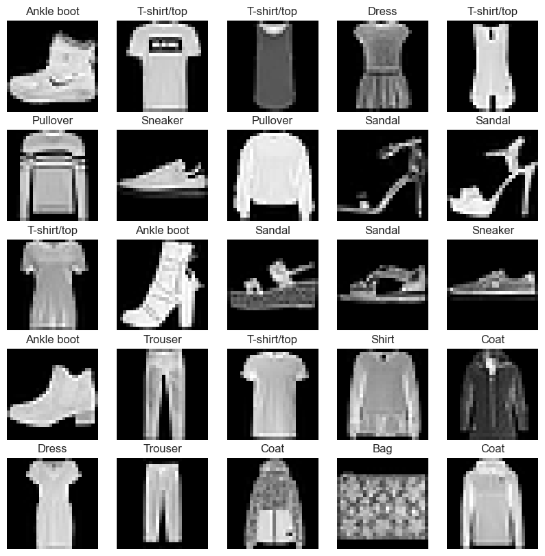

```python
# Load the fMNIST dataset
(x_train, y_train), (x_test, y_test) = fashion_mnist.load_data()

# Preprocess the data
x_train = x_train.reshape((-1, 28, 28, 1)) / 255.0
x_test = x_test.reshape((-1, 28, 28, 1)) / 255.0
y_train = to_categorical(y_train, num_classes=10)
y_test = to_categorical(y_test, num_classes=10)

# Visualize a few samples
class_names = ["T-shirt/top", "Trouser", "Pullover", "Dress", "Coat", "Sandal", "Shirt", "Sneaker", "Bag", "Ankle boot"]

plt.figure(figsize=(10, 10))
for i in range(25):
    plt.subplot(5, 5, i + 1)
    plt.imshow(x_train[i, :, :, 0], cmap="gray")
    plt.title(class_names[np.argmax(y_train[i])])
    plt.axis("off")
plt.show()
```

The provided code visualizes a sample of 25 images along with their corresponding labels for a quick look at the dataset.

Shape of the Data: Training data shape: (60000, 28, 28) - 60,000 images, each of size 28x28 pixels. Testing data shape: (10000, 28, 28) - 10,000 images for evaluation.

There are 10 classes in total, each corresponding to a specific type of clothing item.

#### 2.Train a dense neural network using Keras, try out at least three hyperparameters configurations

```python
from keras.models import Sequential
from keras.layers import Flatten, Dense
from keras.datasets import fashion_mnist
from sklearn.model_selection import train_test_split
```

```python
# Load and preprocess the data
(x_train, y_train), (x_test, y_test) = fashion_mnist.load_data()
x_train, x_val, y_train, y_val = train_test_split(x_train, y_train, test_size=0.2, random_state=42)

x_train = x_train.reshape((-1, 28, 28, 1)) / 255.0
x_val = x_val.reshape((-1, 28, 28, 1)) / 255.0
x_test = x_test.reshape((-1, 28, 28, 1)) / 255.0

y_train = to_categorical(y_train, num_classes=10)
y_val = to_categorical(y_val, num_classes=10)
y_test = to_categorical(y_test, num_classes=10)
```

```python
# Function to create a simple dense neural network model
def create_model(hidden_units, activation_func, optimizer):
    model = Sequential()
    model.add(Flatten(input_shape=(28, 28, 1)))
    model.add(Dense(hidden_units, activation=activation_func))
    model.add(Dense(10, activation='softmax'))

    model.compile(optimizer=optimizer,
                  loss='categorical_crossentropy',
                  metrics=['accuracy'])

    return model
```

```python
# Train and evaluate the model with different hyperparameter configurations
hyperparameter_configs = [
    {'hidden_units': 128, 'activation_func': 'relu', 'optimizer': 'adam'},
    {'hidden_units': 256, 'activation_func': 'sigmoid', 'optimizer': 'sgd'},
    {'hidden_units': 64, 'activation_func': 'tanh', 'optimizer': 'rmsprop'}
]

for config in hyperparameter_configs:
    print(f"Training model with hyperparameters: {config}")
    model = create_model(config['hidden_units'], config['activation_func'], config['optimizer'])
    history = model.fit(x_train, y_train, epochs=10, batch_size=32, validation_data=(x_val, y_val), verbose=2)

    # Evaluate the model on the test set
    test_loss, test_accuracy = model.evaluate(x_test, y_test, verbose=0)
    print(f"Test Accuracy: {test_accuracy*100:.2f}%\n")
```

[output not shown]

[output cut: 54 more lines]

#### Overall, it seems that the model with hyperparameters {'hidden_units': 128, 'activation_func': 'relu', 'optimizer': 'adam'} achieved the highest test accuracy at 88.15%.

#### 3. Evaluate its accuracy for each of the configurations. Choose the best configuration, and: Report its accuracy, confusion metric, and specific examples of incorrect classification, and drew some conclusions from this exploration

```python
!pip install seaborn
```

[output not shown]

```python
from sklearn.metrics import accuracy_score, confusion_matrix
import seaborn as sns
import random
sns.set_theme()
```

```python
# Load and preprocess the data
(x_train, y_train), (x_test, y_test) = fashion_mnist.load_data()
x_train, x_val, y_train, y_val = train_test_split(x_train, y_train, test_size=0.2, random_state=42)

x_train = x_train.reshape((-1, 28, 28, 1)) / 255.0
x_val = x_val.reshape((-1, 28, 28, 1)) / 255.0
x_test = x_test.reshape((-1, 28, 28, 1)) / 255.0

y_train = to_categorical(y_train, num_classes=10)
y_val = to_categorical(y_val, num_classes=10)
y_test = to_categorical(y_test, num_classes=10)

# Function to create a simple dense neural network model
def create_model(hidden_units, activation_func, optimizer):
    model = Sequential()
    model.add(Flatten(input_shape=(28, 28, 1)))
    model.add(Dense(hidden_units, activation=activation_func))
    model.add(Dense(hidden_units // 2, activation=activation_func))  # Additional hidden layer
    model.add(Dense(10, activation='softmax'))

    model.compile(optimizer=optimizer,
                  loss='categorical_crossentropy',
                  metrics=['accuracy'])

    return model
```

```python
# Train and evaluate the model with different hyperparameter configurations
hyperparameter_configs = [
    {'hidden_units': 128, 'activation_func': 'relu', 'optimizer': 'adam'},
    {'hidden_units': 256, 'activation_func': 'sigmoid', 'optimizer': 'sgd'},
    {'hidden_units': 64, 'activation_func': 'tanh', 'optimizer': 'rmsprop'}
]

best_model = None
best_accuracy = 0

for config in hyperparameter_configs:
    print(f"Training model with hyperparameters: {config}")
    model = create_model(config['hidden_units'], config['activation_func'], config['optimizer'])
    history = model.fit(x_train, y_train, epochs=10, batch_size=64, validation_data=(x_val, y_val), verbose=2)

    # Evaluate the model on the validation set
    val_loss, val_accuracy = model.evaluate(x_val, y_val, verbose=0)
    print(f"Validation Accuracy: {val_accuracy*100:.2f}%\n")

    # Check if this configuration has the best accuracy
    if val_accuracy > best_accuracy:
        best_accuracy = val_accuracy
        best_model = model
```

[output not shown]

[output cut: 54 more lines]

The best model hyperparameters {'hidden_units': 128, 'activation_func': 'relu', 'optimizer': 'adam'} achieved the highest validation accuracy of 88.82%.

[output not shown]

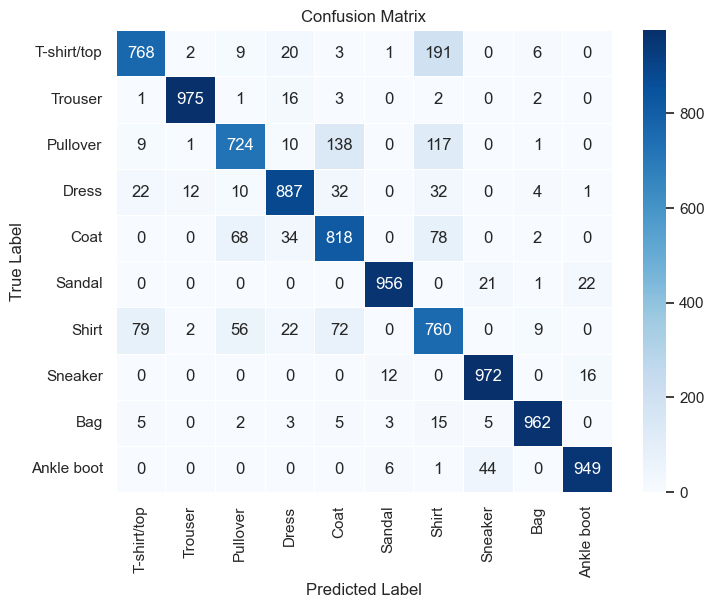

```python
# Evaluate the best model on the test set
test_loss, test_accuracy = best_model.evaluate(x_test, y_test, verbose=0)
print(f"Best Model Test Accuracy: {test_accuracy*100:.2f}%")

# Confusion matrix
y_pred = np.argmax(best_model.predict(x_test), axis=1)
y_true = np.argmax(y_test, axis=1)
conf_matrix = confusion_matrix(y_true, y_pred)

# Plot confusion matrix
plt.figure(figsize=(8, 6))
sns.heatmap(conf_matrix, annot=True, fmt="d", cmap="Blues", linewidths=.5, xticklabels=class_names, yticklabels=class_names)
plt.title("Confusion Matrix")
plt.xlabel("Predicted Label")
plt.ylabel("True Label")
plt.show()
```

#### The best model achieved a test accuracy of 87.71% which is a good result because it presented the unseen data well

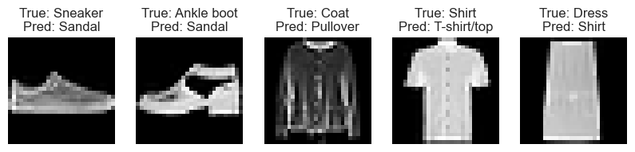

```python
# Find and display specific examples of incorrect classification
incorrect_indices = np.where(y_pred != y_true)[0]
plt.figure(figsize=(10, 5))
for i, incorrect_index in enumerate(incorrect_indices[:5]):
    plt.subplot(1, 5, i + 1)
    plt.imshow(x_test[incorrect_index, :, :, 0], cmap="gray")
    plt.title(f"True: {class_names[y_true[incorrect_index]]}\nPred: {class_names[y_pred[incorrect_index]]}")
    plt.axis("off")
plt.show()
```